# Project: Investigate a Dataset - [No Show - Appointments]

### Data Cleaning

> **In this phase, I will clean every single thing in the data, and fix the data types**

```python
# drop useless columns
# these two columns is useless in my opinion, i'll proofe that in forward ...
useless_columns = ['PatientId', 'AppointmentID']
df = df.drop(columns= useless_columns)
```

```python
# check
df.head()
```

|  | Gender | ScheduledDay | AppointmentDay | Age | Neighbourhood | Scholarship | Hipertension | Diabetes | Alcoholism | Handcap | SMS_received | No-show |
| --- | --- | --- | --- | --- | --- | --- | --- | --- | --- | --- | --- | --- |
| 0 | F | 2016-04-29T18:38:08Z | 2016-04-29T00:00:00Z | 62 | JARDIM DA PENHA | 0 | 1 | 0 | 0 | 0 | 0 | No |
| 1 | M | 2016-04-29T16:08:27Z | 2016-04-29T00:00:00Z | 56 | JARDIM DA PENHA | 0 | 0 | 0 | 0 | 0 | 0 | No |
| 2 | F | 2016-04-29T16:19:04Z | 2016-04-29T00:00:00Z | 62 | MATA DA PRAIA | 0 | 0 | 0 | 0 | 0 | 0 | No |
| 3 | F | 2016-04-29T17:29:31Z | 2016-04-29T00:00:00Z | 8 | PONTAL DE CAMBURI | 0 | 0 | 0 | 0 | 0 | 0 | No |
| 4 | F | 2016-04-29T16:07:23Z | 2016-04-29T00:00:00Z | 56 | JARDIM DA PENHA | 0 | 1 | 1 | 0 | 0 | 0 | No |

```python
# to decrease memory usage
columns_to_convert = ['Age', 'Scholarship', 'Hipertension', 'Diabetes', 'Alcoholism', 'Handcap', 'SMS_received']
for column in columns_to_convert:
    df[column] = df[column].astype('int8')
```

```python
# thats works, let us see if the memory usage decreased or no
df.dtypes
```

```
Gender            object
ScheduledDay      object
AppointmentDay    object
Age                 int8
Neighbourhood     object
Scholarship         int8
Hipertension        int8
Diabetes            int8
Alcoholism          int8
Handcap             int8
SMS_received        int8
No-show           object
dtype: object
```

```python
# awesome! it decrease over than 50% after dropping two useless columns and change the others types!
df.info()
```

```
<class 'pandas.core.frame.DataFrame'>
RangeIndex: 110527 entries, 0 to 110526
Data columns (total 12 columns):
 #   Column          Non-Null Count   Dtype
---  ------          --------------   -----
 0   Gender          110527 non-null  object
 1   ScheduledDay    110527 non-null  object
 2   AppointmentDay  110527 non-null  object
 3   Age             110527 non-null  int8
 4   Neighbourhood   110527 non-null  object
 5   Scholarship     110527 non-null  int8
 6   Hipertension    110527 non-null  int8
 7   Diabetes        110527 non-null  int8
 8   Alcoholism      110527 non-null  int8
 9   Handcap         110527 non-null  int8
 10  SMS_received    110527 non-null  int8
 11  No-show         110527 non-null  object
dtypes: int8(7), object(5)
memory usage: 5.0+ MB
```

```python
df.columns
```

```
Index(['Gender', 'ScheduledDay', 'AppointmentDay', 'Age', 'Neighbourhood',
       'Scholarship', 'Hipertension', 'Diabetes', 'Alcoholism', 'Handcap',
       'SMS_received', 'No-show'],
      dtype='object')
```

```python
# let us now change some columns names, to make dealing with it easier ...
# I will make this inside a dictionary to make the process easier
columns_rename = {'Gender': 'gender', 'ScheduledDay': 'scheduled_day', 'AppointmentDay': 'appointment_day',
                  'Age': 'age','Neighbourhood': 'location', 'Scholarship': 'scholarship',
                  'Hipertension': 'hipertension','Diabetes': 'diabetes', 'Alcoholism': 'alcoholism',
                  'Handcap': 'handcap', 'SMS_received': 'sms_received'}
df = df.rename(columns= columns_rename)
df.head()
# for the column 'No-show', I will deal with it next
```

|  | gender | scheduled_day | appointment_day | age | location | scholarship | hipertension | diabetes | alcoholism | handcap | sms_received | No-show |
| --- | --- | --- | --- | --- | --- | --- | --- | --- | --- | --- | --- | --- |
| 0 | F | 2016-04-29T18:38:08Z | 2016-04-29T00:00:00Z | 62 | JARDIM DA PENHA | 0 | 1 | 0 | 0 | 0 | 0 | No |
| 1 | M | 2016-04-29T16:08:27Z | 2016-04-29T00:00:00Z | 56 | JARDIM DA PENHA | 0 | 0 | 0 | 0 | 0 | 0 | No |
| 2 | F | 2016-04-29T16:19:04Z | 2016-04-29T00:00:00Z | 62 | MATA DA PRAIA | 0 | 0 | 0 | 0 | 0 | 0 | No |
| 3 | F | 2016-04-29T17:29:31Z | 2016-04-29T00:00:00Z | 8 | PONTAL DE CAMBURI | 0 | 0 | 0 | 0 | 0 | 0 | No |
| 4 | F | 2016-04-29T16:07:23Z | 2016-04-29T00:00:00Z | 56 | JARDIM DA PENHA | 0 | 1 | 1 | 0 | 0 | 0 | No |

```python
# working to clean 'No-show'
df.rename(columns={'No-show': 'attendance'}, inplace=True)
```

```python
# according to the dataset source, 'No' = attend, 'Yes' = not attend
# so i will clean it to make the analysis easier (for extra explaination check the Markdown cells above)
df['attendance'] = df['attendance'].replace({'No': 'Y', 'Yes': 'N'})
df['attendance'].value_counts()
```

```
Y    88208
N    22319
Name: attendance, dtype: int64
```

```python
# 'attendence' cleaining ...
df['attendance'] = df['attendance'].replace({'Y': 'yes', 'N': 'no'})
df['attendance'].value_counts()
# good it is clean now
```

```
yes    88208
no     22319
Name: attendance, dtype: int64
```

```python
# change some types into category because they have few unique values to decrease memory usage
columns_to_category = ['gender', 'scholarship', 'hipertension', 'diabetes', 'alcoholism', 'sms_received', 'attendance']
df[columns_to_category] = df[columns_to_category].astype('category')
```

```python
# changing this will help me through analysis
df['scholarship'] = df['scholarship'].replace({1: 'yes', 0: 'no'})
df['hipertension'] = df['hipertension'].replace({1: 'yes', 0: 'no'})
df['diabetes'] = df['diabetes'].replace({1: 'yes', 0: 'no'})
df['alcoholism'] = df['alcoholism'].replace({1: 'yes', 0: 'no'})
df['sms_received'] = df['sms_received'].replace({1: 'yes', 0: 'no'})
```

```python
# changing these columns types to their original types (datetime)
df['scheduled_day'] = pd.to_datetime(df['scheduled_day'])
df['appointment_day'] = pd.to_datetime(df['appointment_day'])
```

```python
# good it changed
df.head()
```

|  | gender | scheduled_day | appointment_day | age | location | scholarship | hipertension | diabetes | alcoholism | handcap | sms_received | attendance |
| --- | --- | --- | --- | --- | --- | --- | --- | --- | --- | --- | --- | --- |
| 0 | F | 2016-04-29 18:38:08+00:00 | 2016-04-29 00:00:00+00:00 | 62 | JARDIM DA PENHA | no | yes | no | no | 0 | no | yes |
| 1 | M | 2016-04-29 16:08:27+00:00 | 2016-04-29 00:00:00+00:00 | 56 | JARDIM DA PENHA | no | no | no | no | 0 | no | yes |
| 2 | F | 2016-04-29 16:19:04+00:00 | 2016-04-29 00:00:00+00:00 | 62 | MATA DA PRAIA | no | no | no | no | 0 | no | yes |
| 3 | F | 2016-04-29 17:29:31+00:00 | 2016-04-29 00:00:00+00:00 | 8 | PONTAL DE CAMBURI | no | no | no | no | 0 | no | yes |
| 4 | F | 2016-04-29 16:07:23+00:00 | 2016-04-29 00:00:00+00:00 | 56 | JARDIM DA PENHA | no | yes | yes | no | 0 | no | yes |

```python
df.dtypes
```

```
gender                        category
scheduled_day      datetime64[ns, UTC]
appointment_day    datetime64[ns, UTC]
age                               int8
location                        object
scholarship                   category
hipertension                  category
diabetes                      category
alcoholism                    category
handcap                           int8
sms_received                  category
attendance                    category
dtype: object
```

```python
# memory usage is getting way lower!, it was 11.8+ and now it's about 3.5
df.info()
```

```
<class 'pandas.core.frame.DataFrame'>
RangeIndex: 110527 entries, 0 to 110526
Data columns (total 12 columns):
 #   Column           Non-Null Count   Dtype
---  ------           --------------   -----
 0   gender           110527 non-null  category
 1   scheduled_day    110527 non-null  datetime64[ns, UTC]
 2   appointment_day  110527 non-null  datetime64[ns, UTC]
 3   age              110527 non-null  int8
 4   location         110527 non-null  object
 5   scholarship      110527 non-null  category
 6   hipertension     110527 non-null  category
 7   diabetes         110527 non-null  category
 8   alcoholism       110527 non-null  category
 9   handcap          110527 non-null  int8
 10  sms_received     110527 non-null  category
 11  attendance       110527 non-null  category
dtypes: category(7), datetime64[ns, UTC](2), int8(2), object(1)
memory usage: 3.5+ MB
```

```python
# now the data is clean and ready to be explored in the next step (EDA)
df
```

|  | gender | scheduled_day | appointment_day | age | location | scholarship | hipertension | diabetes | alcoholism | handcap | sms_received | attendance |
| --- | --- | --- | --- | --- | --- | --- | --- | --- | --- | --- | --- | --- |
| 0 | F | 2016-04-29 18:38:08+00:00 | 2016-04-29 00:00:00+00:00 | 62 | JARDIM DA PENHA | no | yes | no | no | 0 | no | yes |
| 1 | M | 2016-04-29 16:08:27+00:00 | 2016-04-29 00:00:00+00:00 | 56 | JARDIM DA PENHA | no | no | no | no | 0 | no | yes |
| 2 | F | 2016-04-29 16:19:04+00:00 | 2016-04-29 00:00:00+00:00 | 62 | MATA DA PRAIA | no | no | no | no | 0 | no | yes |
| 3 | F | 2016-04-29 17:29:31+00:00 | 2016-04-29 00:00:00+00:00 | 8 | PONTAL DE CAMBURI | no | no | no | no | 0 | no | yes |
| 4 | F | 2016-04-29 16:07:23+00:00 | 2016-04-29 00:00:00+00:00 | 56 | JARDIM DA PENHA | no | yes | yes | no | 0 | no | yes |
| ... | ... | ... | ... | ... | ... | ... | ... | ... | ... | ... | ... | ... |
| 110522 | F | 2016-05-03 09:15:35+00:00 | 2016-06-07 00:00:00+00:00 | 56 | MARIA ORTIZ | no | no | no | no | 0 | yes | yes |
| 110523 | F | 2016-05-03 07:27:33+00:00 | 2016-06-07 00:00:00+00:00 | 51 | MARIA ORTIZ | no | no | no | no | 0 | yes | yes |
| 110524 | F | 2016-04-27 16:03:52+00:00 | 2016-06-07 00:00:00+00:00 | 21 | MARIA ORTIZ | no | no | no | no | 0 | yes | yes |
| 110525 | F | 2016-04-27 15:09:23+00:00 | 2016-06-07 00:00:00+00:00 | 38 | MARIA ORTIZ | no | no | no | no | 0 | yes | yes |
| 110526 | F | 2016-04-27 13:30:56+00:00 | 2016-06-07 00:00:00+00:00 | 54 | MARIA ORTIZ | no | no | no | no | 0 | yes | yes |

110527 rows × 12 columns

## Exploratory Data Analysis

> **In this phase, I will explre each column in the data, discover some insights and answering the questions**

## Simple histograms for each column to better understanding

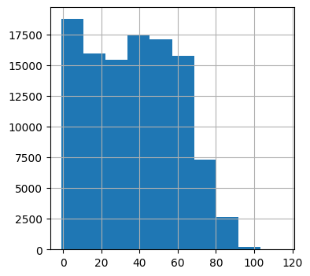

```python
df['age'].hist(figsize=(4,4))
```

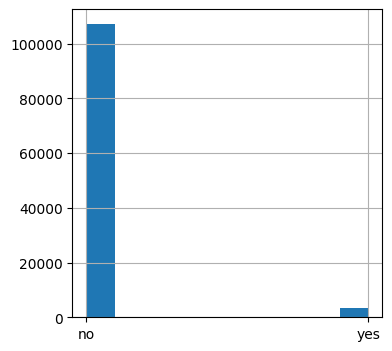

```python
df['alcoholism'].hist(figsize=(4,4))
```

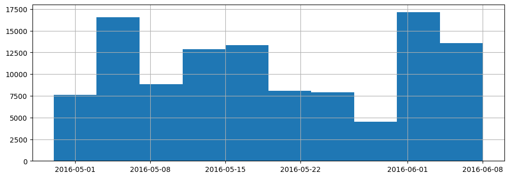

```python
df['appointment_day'].hist(figsize=(12,4))
```

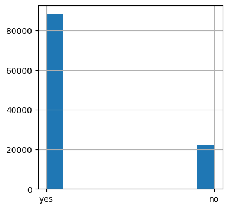

```python
df['attendance'].hist(figsize=(4,4))
```

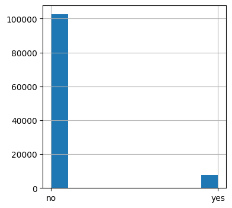

```python
df['diabetes'].hist(figsize=(4,4))
```

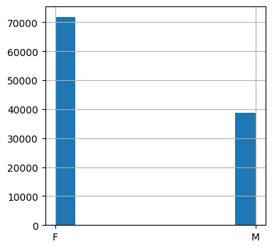

```python
df['gender'].hist(figsize=(4,4))
```

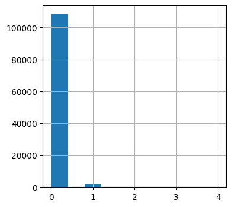

```python
df['handcap'].hist(figsize=(4,4))
```

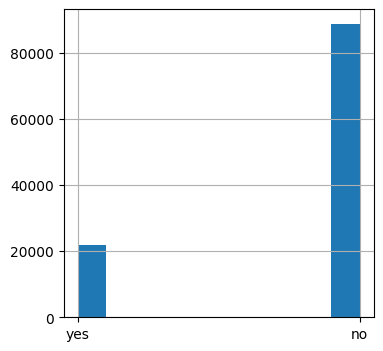

```python
df['hipertension'].hist(figsize=(4,4))
```

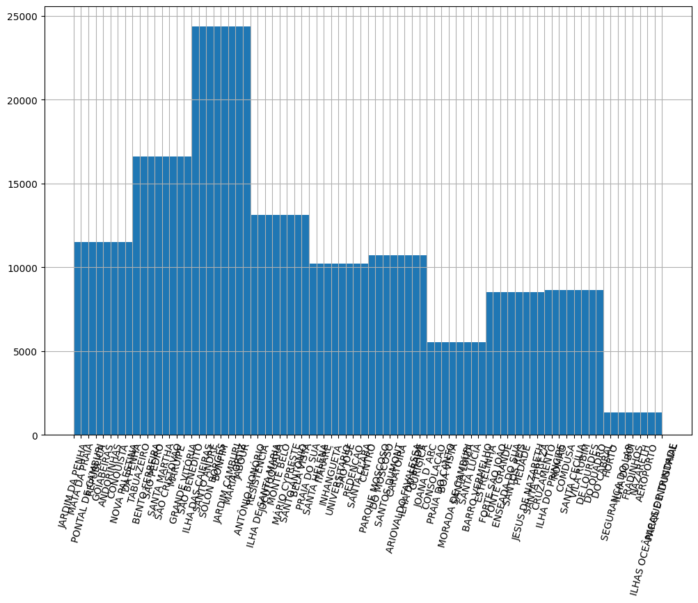

```python
# that's will not work even with the 'rotation'
# below, there is a qustion about it, and there is better understanding of this column
df['location'].hist(figsize=(12,8))
plt.xticks(rotation=75)
plt.show()
```

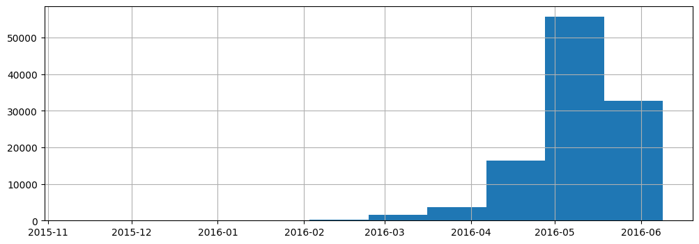

```python
df['scheduled_day'].hist(figsize=(12,4))
```

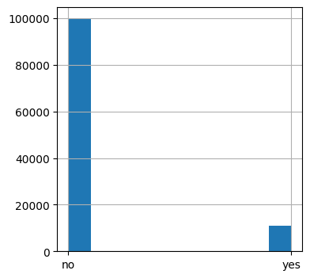

```python
df['scholarship'].hist(figsize=(4,4))
```

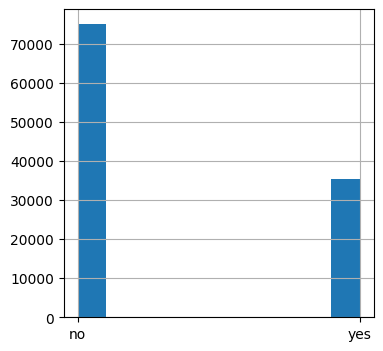

```python
df['sms_received'].hist(figsize=(4,4))
```

### Research Question 1 (How much are the missed appointments from both genders?)

> **I've print the result and plot it also. Females are the most missing appointment than Males!. Down is a barplot explain that.**

```python
# it seems that the females missed appointments more than males as shown in the output
missed_appointments = df[df['attendance'] == 'no'].groupby('gender').size()
print(missed_appointments)
```

```
gender
F    14594
M     7725
dtype: int64
```

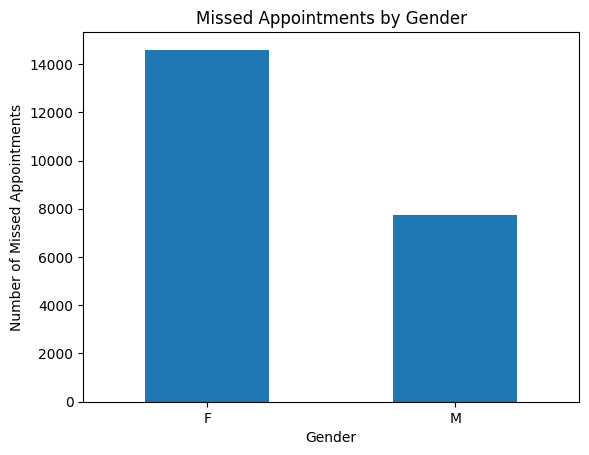

```python
# let us do it inside a bar plot
missed_appointments.plot(kind='bar')
plt.title('Missed Appointments by Gender')
plt.xlabel('Gender')
plt.ylabel('Number of Missed Appointments')
plt.xticks(rotation=0) # to make the 'F' and 'M' vertical
plt.show()
```

### Research Question 2 (What is the most ages that didn't attends appointments and vice versa?)

> **I've answer this question and print the results and visualize it. Babies from 1 months to 12 months are the most ages who missing appointments, then 17, 19 ages after that comes 30!, down is more explaining.**

```python
# 0 is the babie's ages that is lower than 1 year, 1 to 12 months age
# so that what the data says in the brazillian hospitals
ages_missed_appointments = df[df['attendance'] == 'no'].groupby('age').size().reset_index(name='missed_appointments')
top_5_ages_missed = ages_missed_appointments.sort_values(by='missed_appointments', ascending=False).head(5)
print(top_5_ages_missed)
```

```
    age  missed_appointments
0     0                  639
1     1                  415
17   17                  396
19   19                  394
30   30                  369
```

```python
# most 5 ages that attends appointments
ages_attend_appointments = df[df['attendance'] == 'yes'].groupby('age').size().reset_index(name='attend_appointments')
top_5_ages_attends = ages_attend_appointments.sort_values(by='attend_appointments', ascending=False).head(5)
print(top_5_ages_attends)
```

```
    age  attend_appointments
1     0                 2900
2     1                 1858
53   52                 1449
57   56                 1372
3     2                 1366
```

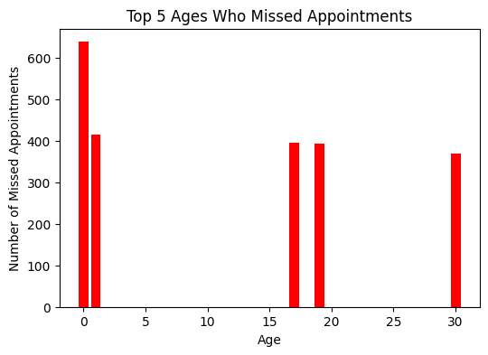

```python
# let's visualize the top 5 ages who missed appointments
plt.figure(figsize=(6, 4))
plt.bar(top_5_ages_missed['age'], top_5_ages_missed['missed_appointments'], color='red')
plt.title('Top 5 Ages Who Missed Appointments')
plt.xlabel('Age')
plt.ylabel('Number of Missed Appointments')
plt.show()
```

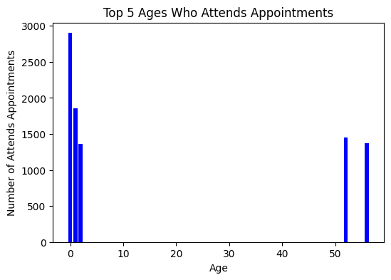

```python
# let's visualize the top 5 ages who attends appointments
plt.figure(figsize=(6, 4))
plt.bar(top_5_ages_attends['age'], top_5_ages_attends['attend_appointments'], color='blue')
plt.title('Top 5 Ages Who Attends Appointments')
plt.xlabel('Age')
plt.ylabel('Number of Attends Appointments')
plt.show()
```

```python
 """
Python function that calculate the percentage of attendance and non-attendance.

returns:
dict: a dictionary with the percentage of attendance and non-attendance.
"""
def calculate_attendance_percentage(df, column, category):
    subset_df = df[df[column] == category]
    total_count = len(subset_df)
    attendance_counts = subset_df['attendance'].value_counts()
    percentage_dict = {
        'Attendance': (attendance_counts['yes'] / total_count) * 100,
        'Non-attendance': (attendance_counts['no'] / total_count) * 100  }
    return percentage_dict

gender_percentage = calculate_attendance_percentage(df, 'gender', 'F')
print("Attendance Percentage for Females:")
print(gender_percentage)
```

```
Attendance Percentage for Females:
{'Attendance': 79.68541202672606, 'Non-attendance': 20.31458797327394}
```

### Research Question 3 (What is the most busy hours that the patients scheduled an appointments at?)

> **In this question, I've created a new column that contains the hour extracted from 'scheduled_day' and stores in 'scheduled_hour', then prints the value counts and plot it.**

```python
# 7:00 am is the most busy time
df['scheduled_hour'] = df['scheduled_day'].dt.hour
busy_times = df['scheduled_hour'].value_counts().sort_index()
print(busy_times)
```

```
6      1578
7     19213
8     15349
9     12823
10    11056
11     8462
12     5422
13     9036
14     9127
15     8079
16     5542
17     2909
18     1340
19      488
20      100
21        3
Name: scheduled_hour, dtype: int64
```

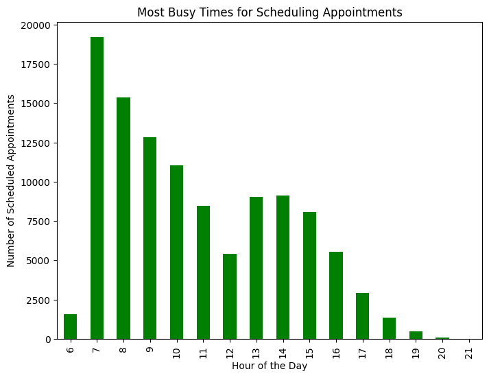

```python
# I've search on google to get help with this plot, it was a little challinging
# extract hour from 'scheduled_day' and store it in a new column
df['scheduled_hour'] = df['scheduled_day'].dt.hour
busy_times = df['scheduled_hour'].value_counts().sort_index()

plt.figure(figsize=(8, 6))
busy_times.plot(kind='bar', color='green')
plt.title('Most Busy Times for Scheduling Appointments')
plt.xlabel('Hour of the Day')
plt.ylabel('Number of Scheduled Appointments')
plt.show()
```

```python
# need to change it's type to decrease memory usage
df['scheduled_hour'] = df['scheduled_hour'].astype('int8')
df.dtypes
```

```
gender                        category
scheduled_day      datetime64[ns, UTC]
appointment_day    datetime64[ns, UTC]
age                               int8
location                        object
scholarship                   category
hipertension                  category
diabetes                      category
alcoholism                    category
handcap                           int8
sms_received                  category
attendance                    category
scheduled_hour                    int8
dtype: object
```

### Research Question 4 (How much the total of patient's attendence and non-attendence, and the different between them?)

> **As I expect, attending the appointments is more than non-attending. The barplot below shows that.**

```python
df['attendance'].value_counts()
```

```
yes    88208
no     22319
Name: attendance, dtype: int64
```

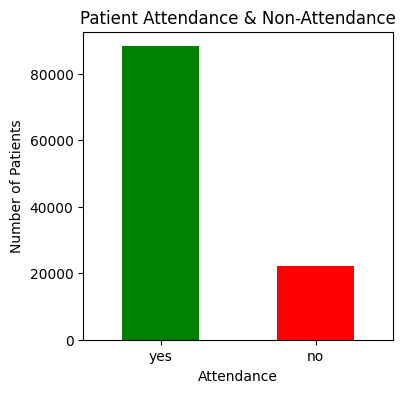

```python
# let us plot the different between them
plt.figure(figsize=(4, 4))
df['attendance'].value_counts().plot(kind='bar', color=['green', 'red'])
plt.title('Patient Attendance & Non-Attendance')
plt.xlabel('Attendance')
plt.ylabel('Number of Patients')
plt.xticks(rotation=0)
plt.show()
```

### Research Question 5 (What is the most locations that have most patients attendnce and non-attendence, and vice versa?)

> **In this question I've print the most attendance appointment in each location and the nieghborhood 'JARDIM CAMBURI' is the most attendance and non-attendance location in the same time. Then I've plot a barchart below.**

```python
# print the top 5 locations in patients attendance
top_attended_locations = df[df['attendance'] == 'yes']['location'].value_counts().head(5)
print('Top 5 attended locations')
print(top_attended_locations)
```

```
Top 5 attended locations
JARDIM CAMBURI     6252
MARIA ORTIZ        4586
RESISTÊNCIA        3525
JARDIM DA PENHA    3246
SANTA MARTHA       2635
Name: location, dtype: int64
```

```python
# print the top 5 location in patients non-attenedance
top_missed_locations = df[df['attendance'] == 'no']['location'].value_counts().head(5)
print('Top 5 missed locations')
print(top_missed_locations)
```

```
Top 5 missed locations
JARDIM CAMBURI    1465
MARIA ORTIZ       1219
ITARARÉ            923
RESISTÊNCIA        906
CENTRO             703
Name: location, dtype: int64
```

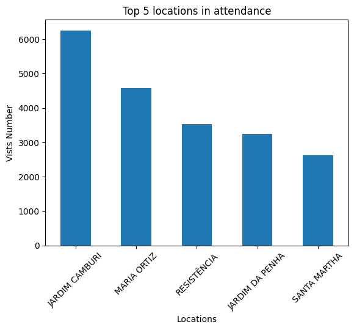

```python
# let's plot it now
top_attended_locations.plot(kind = 'bar')
plt.title('Top 5 locations in attendance')
plt.ylabel('Vists Number')
plt.xlabel('Locations')
plt.xticks(rotation=45)
plt.show()
```

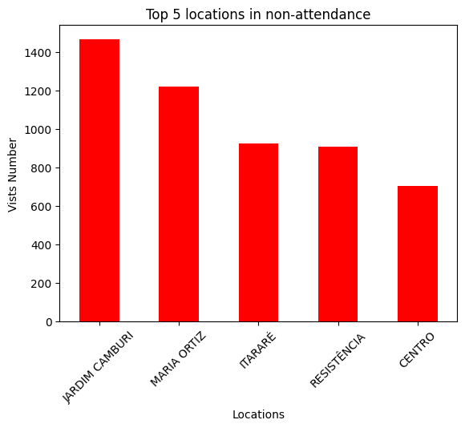

```python
top_missed_locations.plot(kind = 'bar', color='red')
plt.title('Top 5 locations in non-attendance')
plt.ylabel('Vists Number')
plt.xlabel('Locations')
plt.xticks(rotation=45)
plt.show()
```

### Research Question 6 (Does receiving or not receiving SMS affects the patients attendence?)

> **I was intersting of the answer of this question, but the result wasn't that good. I've print the total patients who received and not received the SMS and the result isn't so clear but that's it.**

```python
# this is a little bit wierd lol!, but this is what the data says!
sms_attendance_counts = df.groupby(['sms_received', 'attendance']).size().unstack()
print("Patients who received SMS:")
print(sms_attendance_counts.loc['yes'])
print("\nPatients who did not receive SMS:")
print(sms_attendance_counts.loc['no'])
```

```
Patients who received SMS:
attendance
no      9784
yes    25698
Name: yes, dtype: int64

Patients who did not receive SMS:
attendance
no     12535
yes    62510
Name: no, dtype: int64
```

[figure not shown]

```python
# let's plot them now, 'stacked' is from google search
sms_attendance_counts.plot(kind='bar', stacked=True, color=['green', 'red'])
plt.title('Effect of SMS on Patient Attendance')
plt.xlabel('SMS Received')
plt.ylabel('Number of Patients')
plt.legend(title='Attendance', loc='upper right', labels=['Attended', 'Missed'])
plt.show()
```

### Research Question 7 (What is the most diasesses that the patients have?)

> **In this question I've answer it using pandas library through some codes as shown below. For each disease there is a result of how many patients that they have it, and plot for handcap. So it seems that hipertension is the most common disease according to the data.**

```python
hipertension_count = (df['hipertension'] == 'yes').sum()
print("Number of patients that have hipertension:", hipertension_count)
```

```
Number of patients that have hipertension: 21801
```

```python
diabetes_count = (df['diabetes'] == 'yes').sum()
print("Number of patients that have diabetes:", diabetes_count)
```

```
Number of patients that have diabetes: 7943
```

```python
alcoholism_count = (df['alcoholism'] == 'yes').sum()
print("Number of patients that have alcoholism:", alcoholism_count)
```

```
Number of patients that have alcoholism: 3360
```

```python
# correct it's type
df['handcap'] = df['handcap'].astype('int8')
```

```python
handcap_counts = df['handcap'].value_counts().sort_index()
# print counts for levels 1, 2, 3, and 4 to see the differences
for level in [1, 2, 3, 4]:
    count = handcap_counts.get(level, 0)
    print(f"Number of handcap level {level} that the patients have : {count}")
```

```
Number of handcap level 1 that the patients have : 2042
Number of handcap level 2 that the patients have : 183
Number of handcap level 3 that the patients have : 13
Number of handcap level 4 that the patients have : 3
```

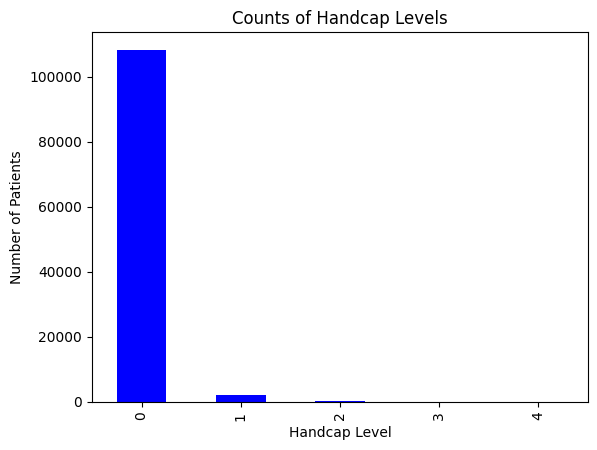

```python
# plot for handcap
handcap_counts.plot(kind='bar', color='blue')
plt.title('Counts of Handcap Levels')
plt.xlabel('Handcap Level')
plt.ylabel('Number of Patients')
plt.show()
```

## Conclusions

> **In conclusion, after analyzing this data regarding patient appointments in Brazilian hospitals, it showed us valuable information that could lead officials to make the appropriate decision. This report contains an analysis and presentation of charts using pandas, matplotlip and numpy. The charts and their types vary from one question to another. After I finished all this, it became clear that Brazilian women do not attend their hospital appointments more than men do, and as for the ages of patients, it does not affect attendance significantly, as I imagined that the elderly are the most absent from appointments, but it appeared that children under one year are the most absent. Perhaps due to the negligence of their families. The busiest time of day for booking appointments is 7 a.m., as I inferred from the data. The hospital, which is located in the “JARDIM CAMBURI” neighborhood, is the most absentee at appointments and also the most present at appointments. I thought that receiving text messages from patients would contribute to an increase in their attendance at appointments, but this does not seem to be the case, because the percentage varies and is not clear. The most common disease that Brazilian patients suffer from is hypertension.**

## Limitaions

> **Data Representativeness:** The dataset utilized in this analysis represents a specific subset of appointments in Brazilian hospitals. It is essential to note that this dataset might not comprehensively reflect the characteristics of the entire population or encompass variations in healthcare practices across different regions or hospitals. If there was an extra columns of patients informations, the analysis will be wide and comprehinsive.

> **Limited Scope of Questions:** The analysis addresses specific questions based on the available data. It might not cover all possible aspects related to patient attendance, and there could be additional questions or dimensions worth exploring.

> **Duplicates:** There was 48,000+ duplicated values for the column 'PatientId', but I decided to drop it.

## Suggistions For Upcoming Studies

> **Some way, add an extra columns for patients info which will make the analysis wider.**

> **Add extra types of plots to make the notebook more clear and understandable.**

# For Contact

## LinkedIn: Waleed Alhumizi

```python
# Running this cell will execute a bash command to convert this notebook to an .html file
!python -m nbconvert --to html Investigate_a_Dataset_Resubmit.ipynb
```

[output not shown]